# Modeling for Animal Shelter Data

```r
load(file="rf_final_fit.rda")
final_pred_rf <- predict(final_fit_rf, newdata=testing.set)
rfConfusion <- confusionMatrix(data=final_pred_rf, testing.set$OutcomeType)
```

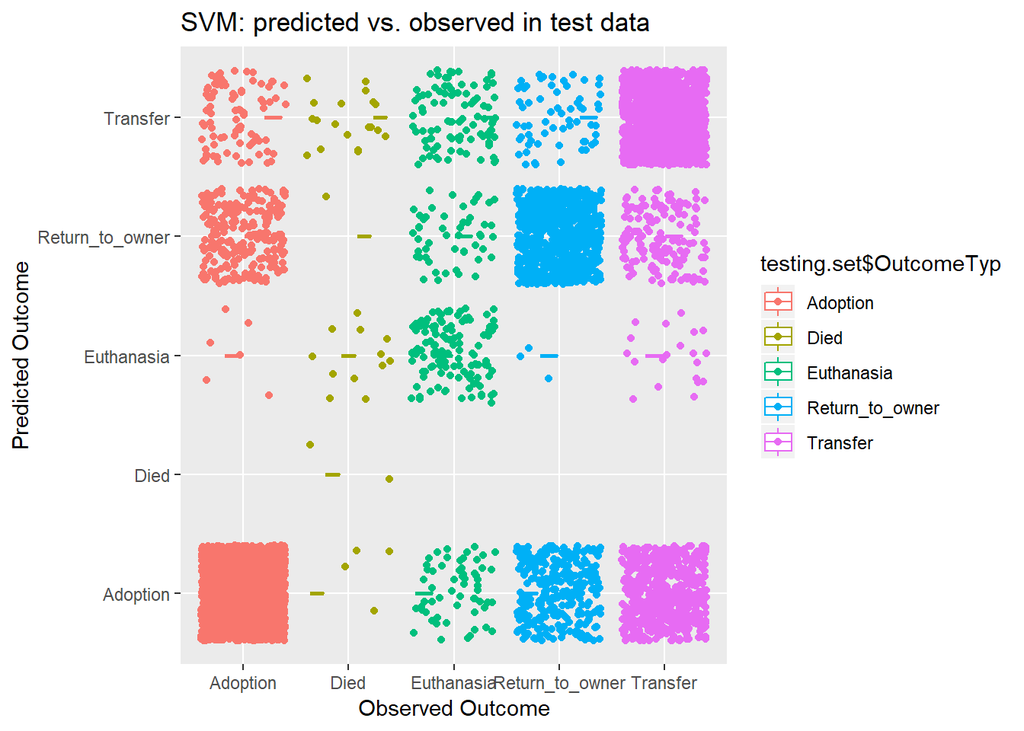

```r
qplot(testing.set$OutcomeType, final_pred_rf,  colour= testing.set$OutcomeTyp,
      geom = c("boxplot", "jitter"),
      main = "SVM: predicted vs. observed in test data",
      xlab = "Observed Outcome",
      ylab = "Predicted Outcome")
```

# Model Evaluation We have been continually evaluating models for each of the 4 models, but here we will compare on metrics that we care most about. For the animal shelter, we determined that the following metrics are more important:

```r
eval_matrix <- outcomes[,"OutcomeType"]
eval_matrix[,c("XGBoost", "Multinomial", "SVM", "RandomForest")] <- NA

for (class in eval_matrix$OutcomeType) {
  if (class %in% c("Adoption", "Return_to_owner")) {
    evalMetric <- "Sensitivity"
  } else if (class %in% c("Adoption", "Return_to_owner")) {
    evalMetric <- "Specificity"
  } else if (class == "Transfer") {
    evalMetric <- "Balanced Accuracy"
  }
  eval_matrix[eval_matrix$OutcomeType==class,"XGBoost"] <- xgb_conf$byClass[paste0("Class: ", class), evalMetric]
  eval_matrix[eval_matrix$OutcomeType==class,"Multinomial"] <- multiNomOut_conf$byClass[paste0("Class: ", class), evalMetric]
  eval_matrix[eval_matrix$OutcomeType==class,"SVM"] <- svmConfusion$byClass[paste0("Class: ", class), evalMetric]
  eval_matrix[eval_matrix$OutcomeType==class,"RandomForest"] <- svmConfusion$byClass[paste0("Class: ", class), evalMetric]
}
eval_matrix[is.na(eval_matrix)] <- 0
eval_matrix <- eval_matrix %>%
  mutate(bestModel = max.col(eval_matrix[,-1], ties.method = "last")) %>%
  mutate(bestModel = ifelse(bestModel == 4, "RandomForest",
                      ifelse(bestModel == 1, "XGBoost",
                             ifelse(bestModel == 2, "Multinomial",
                                    ifelse(bestModel == 3, "SVM", "")))))
print(eval_matrix)
```

```
## # A tibble: 5 x 6
##   OutcomeType     XGBoost Multinomial   SVM RandomForest bestModel
##   <chr>             <dbl>       <dbl> <dbl>        <dbl> <chr>
## 1 Adoption          0.682       0.657 0.841        0.841 RandomForest
## 2 Died              0.25        0     0            0     XGBoost
## 3 Euthanasia        0.658       0.526 0.348        0.348 XGBoost
## 4 Return_to_owner   0.607       0.606 0.673        0.673 RandomForest
## 5 Transfer          0.805       0.791 0.752        0.752 XGBoost
```

## Enhancements and Recommendations for Further Optimizing Animal Shelters Data Models

Having completed our EDA and data modeling for the Austin Animal Shelter Kaggle competition, we discussed a group what could be done in order to better assist the Austin Animal Center and our models to be able to make more accurate outcome predictions. We came up with a couple of recommendations for the animal center, as well as some enhancements we could do currently if we had more time, to be able to produce more accurate and useful results to help these animals recieve better outcomes.

Enhancements to the process we did: * Look to leverage the color variable that was supplied in the Kaggle dataset. We had to ignore this variable due to the fact that this variable contained thousands of minor variations and combinations in fur color that we did not have time to try and categorize or group. With more time, we would come up with an accurately and detailed categorization system that would allows us to group animals together based on fur color and combinations in order to allows us to dummify and leverage this column in our models. Since most models can’t train if a variable has more than 53 categories (and we didn’t want our dummify to produce thousands of distinct columns for all the color combinations), we would want to create a more targetted color categorization system.

- Split up our data set into two new datasets, one for cats and one for dogs, and look to train individual models for each animal type. This would help to remove some of the confusion in our models that having the two types of animals and all their breed and color combinations in the same dataset produced.

Recommendations: * If we were to split our dataset up into datasets for cats and dogs, we would then love to work with the Austin Animal Center to collect and utilize additional information that unique to those type of animals. For example, for cats it would be very useful to know if the cat is de-clawed or not, since this is often a major factor in people being willing or able to adopt a cat, since clawed cats can damage furniture or carpets.

- Working with the Austin Animal Center to collect additional general information about their shelter animals. We feel that information like animal intake weight, geo-coded locations for where the animal was found, or if the animal had prior surgeries would be very helpful in being able to better predict animal outcomes with our ML models.